# Population parameters

J. Ignacio Lucas Lledó

2026-01-02

# Introduction

The estimation of population parameters (basically, nucleotide diversity and inbreeding) is complex, and I became entangled in a previous folder. I will try to streamline the process and get conclusions. The plan is:

0. Explore the relationship between allele frequency and HWE *p*-value, in order to set a reasonable threshold not biasing the SFS.
1. Re-estimate SFS for the two populations and for every individual, from both alignments, to the reference and to the RAD loci.
2. Estimate individual-level of inbreeding.
3. Estimate $F_{ST}$ again (it was done in `2024-10-10`).
4. Maybe estimate error rates for the two populations (Kim, S.Y. and Lohmueller, K.E. and Albrechtsen, A. and Li, Y. and Korneliussen, T. and Tian, G. and Grarup, N. and Jiang, T. and Andersen, G. and Witte, D. and Jorgensen, T. and Hansen, T. and Pedersen, O. and Wang, J. and Nielsen, R. 2011), and for the two types of input data.

# Preparing data

```bash
RADBAM=../2024-10-04/BAM
REFBAM=../2023-05-18/BAM
RADREF=../2024-10-04/radloci.fa
REFREF=../2023-05-15/assembly.fasta

if [ ! -d ref ]; then mkdir ref; fi
if [ ! -d rad ]; then mkdir rad; fi

if [ ! -e farionis.txt ]; then
   gawk '((NR > 1) && ($3 > 0.95) && ($1 ~ /^L/)){
      print $1
   }' ../2024-10-05/summary.txt | sort > farionis.txt
fi
if [ ! -e pseudofarionis.txt ]; then
   gawk '((NR > 1) && ($2 > 0.95) && ($1 ~ /^S/)){
      print $1
   }' ../2024-10-05/summary.txt | sort > pseudofarionis.txt
fi
if [ ! -e admixed.txt ]; then
   gawk '((NR > 1) && ($2 < 0.95) && ($3 < 0.95)){
      print $1
   }' ../2024-10-05/summary.txt | sort > admixed.txt
fi
if [ ! -e uncertain.txt ]; then
   # Includes samples from Bienne, but also individuals without
   # enough data.
   find $REFBAM -name '*.bam' | \
   grep -v -F -f farionis.txt | \
   grep -v -F -f pseudofarionis.txt | \
   grep -v -F -f admixed.txt | \
   xargs basename -s .bam > uncertain.txt

   find $RADBAM -name '*.bam' | \
   grep -v -F -f others.txt | \
   xargs basename -s .bam > z.txt

   if [ ! -s z.txt ]; then cat z.txt >> uncertain.txt; fi
   if [ -e z.txt ]; then rm z.txt; fi
fi

for pop in farionis pseudofarionis admixed; do
   if [ ! -e ref/$pop.list ]; then
      find $REFBAM -name '*.bam' | grep -f $pop.txt | sort > ref/$pop.list
   fi
   if [ ! -e rad/$pop.list ]; then
      find $RADBAM -name '*.bam' | grep -f $pop.txt | sort > rad/$pop.list
   fi
done

if [ ! -d ref/SFS ]; then mkdir ref/SFS; fi
if [ ! -d rad/SFS ]; then mkdir rad/SFS; fi
if [ ! -d ref/SFS/unfiltered ]; then mkdir ref/SFS/unfiltered; fi
if [ ! -d rad/SFS/unfiltered ]; then mkdir rad/SFS/unfiltered; fi
# No need of SFS for the admixed
for pop in farionis pseudofarionis; do
   if [ ! -e ref/SFS/unfiltered/$pop.saf.idx ]; then
      angsd -b ref/$pop.list \
            -anc $REFREF \
            -ref $REFREF \
            -out ref/SFS/unfiltered/$pop \
            -doGlf 1 \
            -GL 1 \
            -doSaf 1 \
            -doHWE 1 \
            -doMajorMinor 1 \
            -minmapQ 30 \
            -minQ 20 \
            -only_proper_pairs 1 \
            -baq 1 \
            -minInd $(( $(cat ref/$pop.list | wc -l) * 4 / 5 )) \
            -setMinDepthInd 4 \
            -nThreads 8 1> ref/SFS/unfiltered/$pop.log \
            2> ref/SFS/unfiltered/$pop.err &
   fi
   if [ ! -e rad/SFS/unfiltered/$pop.saf.idx ]; then
      angsd -b rad/$pop.list \
            -anc $RADREF \
            -ref $RADREF \
            -out rad/SFS/unfiltered/$pop \
            -doGlf 1 \
            -GL 1 \
            -doSaf 1 \
            -doHWE 1 \
            -doMajorMinor 1 \
            -minmapQ 30 \
            -minQ 20 \
            -only_proper_pairs 1 \
            -baq 1 \
            -minInd $(( $(cat rad/$pop.list | wc -l) * 4 / 5 )) \
            -setMinDepthInd 4 \
            -nThreads 8 1> rad/SFS/unfiltered/$pop.log \
            2> rad/SFS/unfiltered/$pop.err &
   fi
done
wait

for pop in farionis pseudofarionis; do
   if [ ! -e ref/SFS/unfiltered/$pop.sfs ]; then
      realSFS -fold 1 ref/SFS/unfiltered/$pop.saf.idx \
              1> ref/SFS/unfiltered/$pop.sfs \
              2> ref/SFS/unfiltered/$pop.sfs.err &
   fi

   if [ ! -e rad/SFS/unfiltered/$pop.sfs ]; then
      realSFS -fold 1 rad/SFS/unfiltered/$pop.saf.idx \
              1> rad/SFS/unfiltered/$pop.sfs \
              2> rad/SFS/unfiltered/$pop.sfs.err &
   fi
done
wait
```

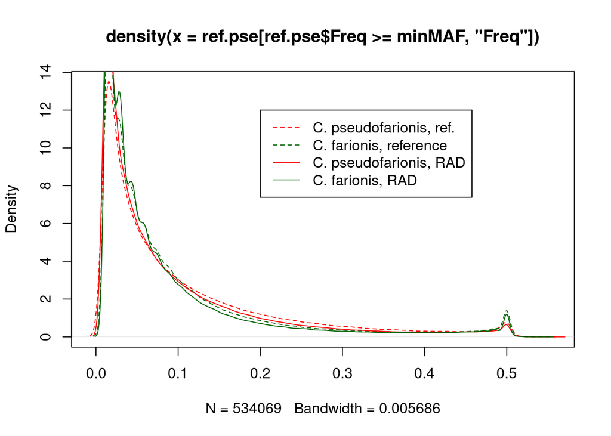

```r
library(ggplot2)
minMAF <- 0.01
ref.pse <- read.table('ref/SFS/unfiltered/pseudofarionis.hwe.gz',
                      header = TRUE)
ref.far <- read.table('ref/SFS/unfiltered/farionis.hwe.gz',
                      header = TRUE)
rad.pse <- read.table('rad/SFS/unfiltered/pseudofarionis.hwe.gz',
                      header = TRUE)
rad.far <- read.table('rad/SFS/unfiltered/farionis.hwe.gz',
                      header = TRUE)

 plot(density(ref.pse[ref.pse$Freq >= minMAF, 'Freq']), lty = 2, col = 'red')
lines(density(ref.far[ref.far$Freq >= minMAF, 'Freq']), lty = 2, col = 'darkgreen')
lines(density(rad.pse[rad.pse$Freq >= minMAF, 'Freq']), lty = 1, col = 'red')
lines(density(rad.far[rad.far$Freq >= minMAF, 'Freq']), lty = 1, col = 'darkgreen')
legend(0.2, 12, c('C. pseudofarionis, ref.',
                  'C. farionis, reference',
                  'C. pseudofarionis, RAD',
                  'C. farionis, RAD'),
       lty = c(2, 2, 1, 1),
       col = c('red', 'darkgreen', 'red', 'darkgreen'))
```

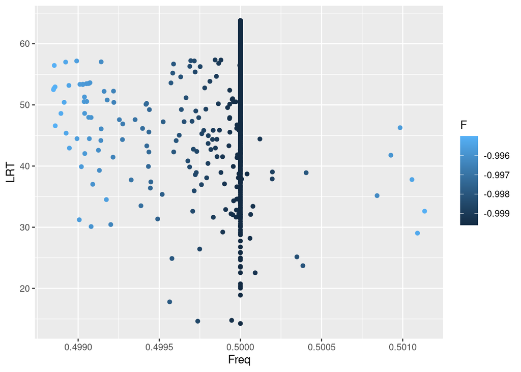

```r
f <- ref.pse$Freq > 0.45 & ref.pse$F < -0.995
ggplot(ref.pse[f,], aes(x = Freq, y = LRT, color = F)) + geom_point()
```

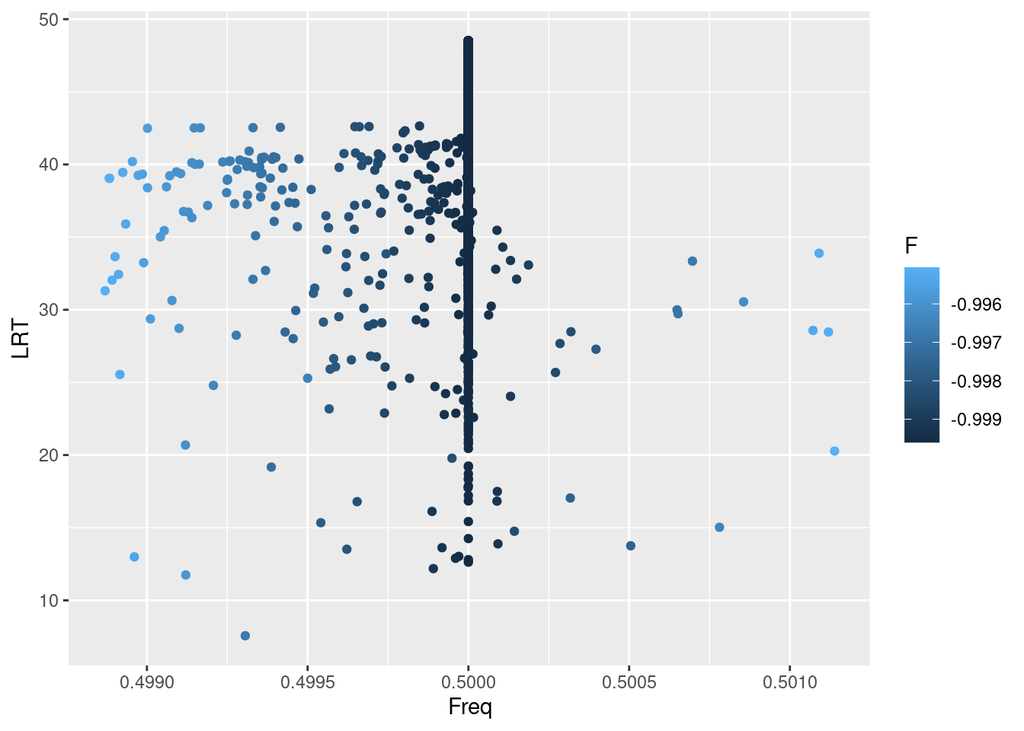

```r
f <- ref.far$Freq > 0.45 & ref.far$F < -0.995
ggplot(ref.far[f,], aes(x = Freq, y = LRT, color = F)) + geom_point()
```

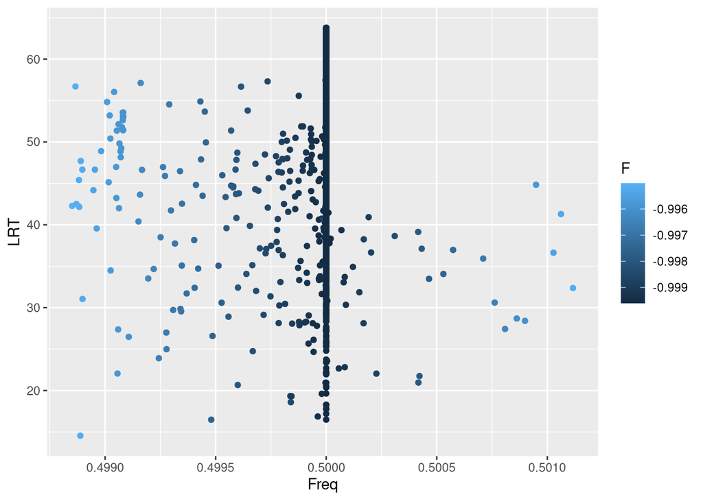

```r
f <- rad.pse$Freq > 0.45 & rad.pse$F < -0.995
ggplot(rad.pse[f,], aes(x = Freq, y = LRT, color = F)) + geom_point()
```

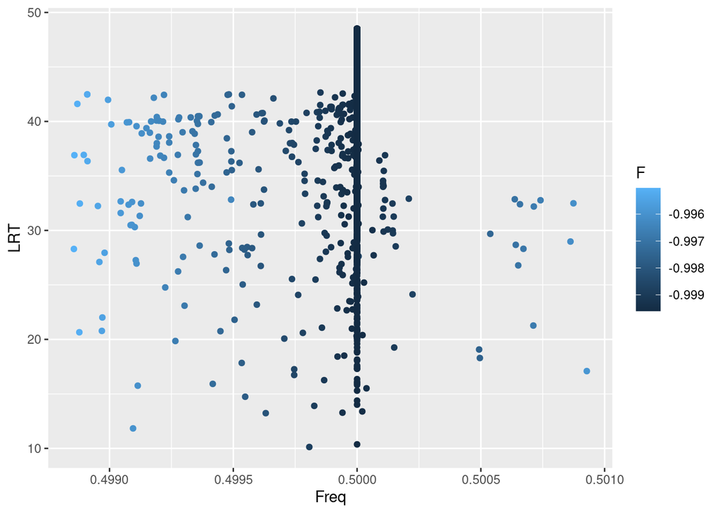

```r
f <- rad.far$Freq > 0.45 & rad.far$F < -0.995
ggplot(rad.far[f,], aes(x = Freq, y = LRT, color = F)) + geom_point()
```

Apparently, the excess of 50%-frequency sites is caused by the only sites having the minimum (negative, close to -1) inbreeding coefficient in all data sets. This confirms that that the excess of such anomalous sites can be removed by a more specific filter than just setting a *p*-value threshold. I can identify and remove those sites by their extreme $F$ value, for example.

```r
if (! file.exists('ref/SFS/unfiltered/pseudofarionis.sites.txt')) {
   write.table(ref.pse[ref.pse$F > min(ref.pse$F), c('Chromo', 'Position')],
               file = 'ref/SFS/unfiltered/pseudofarionis.sites.txt', sep = '\t',
               quote = FALSE, row.names = FALSE, col.names = FALSE)
}
if (! file.exists('ref/SFS/unfiltered/farionis.sites.txt')) {
   write.table(ref.far[ref.far$F > min(ref.far$F), c('Chromo', 'Position')],
               file = 'ref/SFS/unfiltered/farionis.sites.txt', sep = '\t',
               quote = FALSE, row.names = FALSE, col.names = FALSE)
}
if (! file.exists('rad/SFS/unfiltered/pseudofarionis.sites.txt')) {
   write.table(rad.pse[rad.pse$F > min(rad.pse$F), c('Chromo', 'Position')],
               file = 'rad/SFS/unfiltered/pseudofarionis.sites.txt', sep = '\t',
               quote = FALSE, row.names = FALSE, col.names = FALSE)
}
if (! file.exists('rad/SFS/unfiltered/farionis.sites.txt')) {
   write.table(rad.far[rad.far$F > min(rad.far$F), c('Chromo', 'Position')],
               file = 'rad/SFS/unfiltered/farionis.sites.txt', sep = '\t',
               quote = FALSE, row.names = FALSE, col.names = FALSE)
}
```

```bash
if [ ! -e ref/SFS/unfiltered/pseudofarionis.sites.txt.idx ]; then
   angsd sites index ref/SFS/unfiltered/pseudofarionis.sites.txt \
   2>&1 > ref/SFS/unfiltered/pseudofarionis.sites.err
fi
if [ ! -e ref/SFS/unfiltered/farionis.sites.txt.idx ]; then
   angsd sites index ref/SFS/unfiltered/farionis.sites.txt \
   2>&1 > ref/SFS/unfiltered/farionis.sites.err
fi
if [ ! -e rad/SFS/unfiltered/pseudofarionis.sites.txt.idx ]; then
   angsd sites index rad/SFS/unfiltered/pseudofarionis.sites.txt \
   2>&1 > rad/SFS/unfiltered/pseudofarionis.sites.err
fi
if [ ! -e rad/SFS/unfiltered/farionis.sites.txt.idx ]; then
   angsd sites index rad/SFS/unfiltered/farionis.sites.txt \
   2>&1 > rad/SFS/unfiltered/farionis.sites.err
fi

if [ ! -e ref/SFS/unfiltered/pseudofarionis.chr.txt ]; then
   cut -f 1 ref/SFS/unfiltered/pseudofarionis.sites.txt | sort | \
   uniq > ref/SFS/unfiltered/pseudofarionis.chr.txt
fi

if [ ! -e ref/SFS/unfiltered/farionis.chr.txt ]; then
   cut -f 1 ref/SFS/unfiltered/farionis.sites.txt | sort | \
   uniq > ref/SFS/unfiltered/farionis.chr.txt
fi

if [ ! -e rad/SFS/unfiltered/pseudofarionis.chr.txt ]; then
   cut -f 1 rad/SFS/unfiltered/pseudofarionis.sites.txt | sort | \
   uniq > rad/SFS/unfiltered/pseudofarionis.chr.txt
fi

if [ ! -e rad/SFS/unfiltered/farionis.chr.txt ]; then
   cut -f 1 rad/SFS/unfiltered/farionis.sites.txt | sort | \
   uniq > rad/SFS/unfiltered/farionis.chr.txt
fi
```

```bash
RADBAM=../2024-10-04/BAM
REFBAM=../2023-05-18/BAM
RADREF=../2024-10-04/radloci.fa
REFREF=../2023-05-15/assembly.fasta

# No need of SFS for the admixed
for pop in farionis pseudofarionis; do
   if [ ! -e ref/SFS/$pop.saf.idx ]; then
      angsd -b ref/$pop.list \
            -anc $REFREF \
            -ref $REFREF \
            -rf    ref/SFS/unfiltered/$pop.chr.txt \
            -sites ref/SFS/unfiltered/$pop.sites.txt \
            -out ref/SFS/$pop \
            -doGlf 1 \
            -GL 1 \
            -doSaf 1 \
            -doMajorMinor 1 \
            -minmapQ 30 \
            -minQ 30 \
            -only_proper_pairs 1 \
            -baq 1 \
            -minInd $(( $(cat ref/$pop.list | wc -l) * 4 / 5 )) \
            -setMinDepthInd 4 \
            -nThreads 8 1> ref/SFS/$pop.log \
            2> ref/SFS/$pop.err &
   fi
   if [ ! -e rad/SFS/$pop.saf.idx ]; then
      angsd -b rad/$pop.list \
            -anc $RADREF \
            -ref $RADREF \
            -rf    rad/SFS/unfiltered/$pop.chr.txt \
            -sites rad/SFS/unfiltered/$pop.sites.txt \
            -out rad/SFS/$pop \
            -doGlf 1 \
            -GL 1 \
            -doSaf 1 \
            -doMajorMinor 1 \
            -minmapQ 30 \
            -minQ 30 \
            -only_proper_pairs 1 \
            -baq 1 \
            -minInd $(( $(cat rad/$pop.list | wc -l) * 4 / 5 )) \
            -setMinDepthInd 4 \
            -nThreads 8 1> rad/SFS/$pop.log \
            2> rad/SFS/$pop.err &
   fi
done
wait

for pop in farionis pseudofarionis; do
   if [ ! -e ref/SFS/$pop.sfs ]; then
      realSFS -fold 1 ref/SFS/$pop.saf.idx \
      1> ref/SFS/$pop.sfs 2> ref/SFS/$pop.sfs.err &
   fi

   if [ ! -e rad/SFS/$pop.sfs ]; then
      realSFS -fold 1 rad/SFS/$pop.saf.idx \
      1> rad/SFS/$pop.sfs 2> rad/SFS/$pop.sfs.err &
   fi
done
wait
```

# Nucleotide diversity

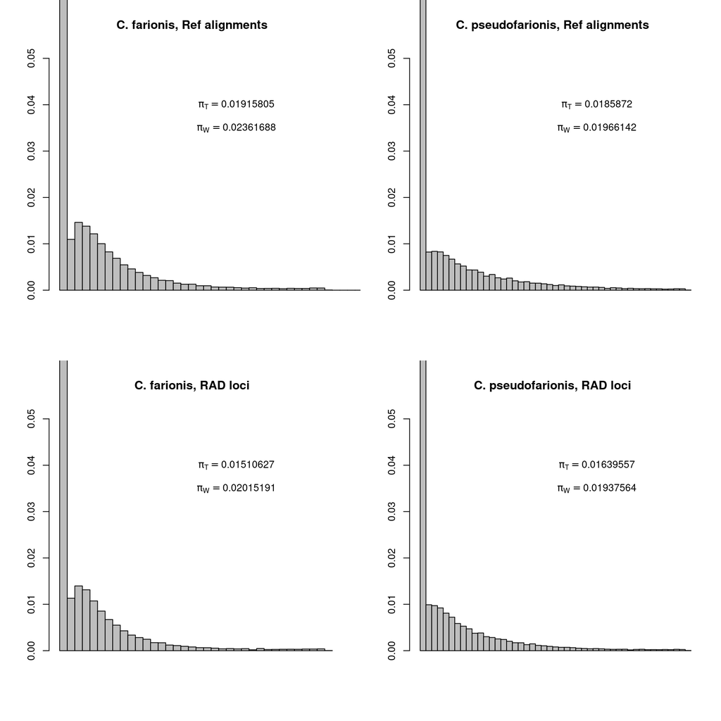

```r
PiTajima <- function(x, folded = TRUE){
   n <- length(x) - 1  # the SFS includes invariable sites and, if folded, 0 values for i > n/2
   a <- 1:(n/2)
   Theta <- (2/(n * (n-1))) * sum(x[2:(n/2 + 1)] * a * (n - a)) / sum(x)
   return(Theta)
}
PiWatterson <- function(x, folded = TRUE){
   n <- length(x) - 1
   a <- sum(1/(1:(n-1)))
   Theta <- sum(x[-1]) / (a * sum(x))
   return(Theta)
}

# SFS data and calculations
far.ref <- scan('ref/SFS/farionis.sfs', quiet = TRUE)
far.n <- (length(far.ref) - 1) / 2
far.ref.pi.T <- PiTajima(far.ref)
far.ref.pi.W <- PiWatterson(far.ref)

far.rad <- scan('rad/SFS/farionis.sfs', quiet = TRUE)
far.rad.pi.T <- PiTajima(far.rad)
far.rad.pi.W <- PiWatterson(far.rad)


pse.ref <- scan('ref/SFS/pseudofarionis.sfs', quiet = TRUE)
pse.n <- (length(pse.ref) - 1) / 2
pse.ref.pi.T <- PiTajima(pse.ref)
pse.ref.pi.W <- PiWatterson(pse.ref)

pse.rad <- scan('rad/SFS/pseudofarionis.sfs', quiet = TRUE)
pse.rad.pi.T <- PiTajima(pse.rad)
pse.rad.pi.W <- PiWatterson(pse.rad)

# Plotting
par(mfrow = c(2, 2))
plot(c(0, far.n), c(0, 0.05), type = 'n', xlab = '', ylab = '', axes = FALSE,
     main = 'C. farionis, Ref alignments')
barplot(far.ref / sum(far.ref), add = TRUE, space = 0)
text(2 * far.n / 3, 0.040,
     bquote(pi[T]==.(far.ref.pi.T)))
text(2 * far.n / 3, 0.035,
     bquote(pi[W]==.(far.ref.pi.W)))

plot(c(0, pse.n), c(0, 0.05), type = 'n', xlab = '', ylab = '', axes = FALSE,
     main = 'C. pseudofarionis, Ref alignments')
barplot(pse.ref[1:(pse.n + 1)] / sum(pse.ref), add = TRUE, space = 0)
text(2 * pse.n / 3, 0.040,
     bquote(pi[T]==.(pse.ref.pi.T)))
text(2 * pse.n / 3, 0.035,
     bquote(pi[W]==.(pse.ref.pi.W)))

plot(c(0, far.n), c(0, 0.05), type = 'n', xlab = '', ylab = '', axes = FALSE,
     main = 'C. farionis, RAD loci')
barplot(far.rad[1:(far.n + 1)] / sum(far.rad), add = TRUE, space = 0)
text(2 * far.n / 3, 0.040,
     bquote(pi[T]==.(far.rad.pi.T)))
text(2 * far.n / 3, 0.035,
     bquote(pi[W]==.(far.rad.pi.W)))

plot(c(0, pse.n), c(0, 0.05), type = 'n', xlab = '', ylab = '', axes = FALSE,
     main = 'C. pseudofarionis, RAD loci')
barplot(pse.rad[1:(pse.n + 1)] / sum(pse.rad), add = TRUE, space = 0)
text(2 * pse.n / 3, 0.040,
     bquote(pi[T]==.(pse.rad.pi.T)))
text(2 * pse.n / 3, 0.035,
     bquote(pi[W]==.(pse.rad.pi.W)))
```

Watterson estimates of nucleotide diversity are slightly higher in both populations. This suggests an excess of low frequency variants, especially in *C. farionis*, despite an apparent bias against singletons. An excess of low frequency variants is indicative of population expansion.

# Individual heterozygosity

We can estimate heterozygosity of all individuals, including the admixed ones, or the ones for which we have less data. It may make sense to use a common subset of sites. For example, the sites that are valid in both populations.

```bash
RADBAM=../2024-10-04/BAM
REFBAM=../2023-05-18/BAM
RADREF=../2024-10-04/radloci.fa
REFREF=../2023-05-15/assembly.fasta

if [ ! -d ref/indH ]; then mkdir ref/indH; fi
if [ ! -d rad/indH ]; then mkdir rad/indH; fi

if [ ! -e ref/indH/goodchr.txt ]; then
   if [ ! -e ref/indH/sites.txt.idx ]; then
      if [ ! -e ref/indH/sites.txt ]; then
         cat ref/SFS/unfiltered/pseudofarionis.sites.txt \
             ref/SFS/unfiltered/farionis.sites.txt | \
         gawk -v OFS="\t" '{
            F[$0]++
            if (F[$0] == 2) print $0
         }' > ref/indH/sites.txt
      fi
      angsd sites index ref/indH/sites.txt \
            2>&1 > ref/indH/sites.err
   fi
   cut -f 1 ref/indH/sites.txt | sort | uniq > ref/indH/goodchr.txt
fi
if [ ! -e rad/indH/goodchr.txt ]; then
   if [ ! -e rad/indH/sites.txt.idx ]; then
      if [ ! -e rad/indH/sites.txt ]; then
         cat rad/SFS/unfiltered/pseudofarionis.sites.txt \
             rad/SFS/unfiltered/farionis.sites.txt | \
         gawk -v OFS="\t" '{
            F[$0]++
            if (F[$0] == 2) print $0
         }' > rad/indH/sites.txt
      fi
      angsd sites index rad/indH/sites.txt \
      2>&1 > rad/indH/sites.err
   fi
   cut -f 1 rad/indH/sites.txt | sort | uniq > rad/indH/goodchr.txt
fi

if [ ! -e ref/indH/samples.txt ]; then
   find $REFBAM -name '*.bam' | xargs basename -s .bam > ref/indH/samples.txt
fi
if [ ! -e rad/indH/samples.txt ]; then
   find $RADBAM -name '*.bam' | xargs basename -s .bam > rad/indH/samples.txt
fi

split -l 16 -d ref/indH/samples.txt ref/indH/batch
for batch in $(ls -1 ref/indH/batch*); do
   for i in $(cat $batch); do
      if [ ! -e ref/indH/$i.saf.idx ]; then
         echo $REFBAM/$i.bam > ref/indH/$i.list
         angsd -bam ref/indH/$i.list \
               -anc $REFREF \
               -ref $REFREF \
               -out   ref/indH/$i \
               -rf    ref/indH/goodchr.txt \
               -sites ref/indH/sites.txt \
               -doGlf 1 \
               -GL 1 \
               -doSaf 1 \
               -minmapQ 30 \
               -minQ 30 \
               -only_proper_pairs 1 \
               -baq 1 \
               -setMinDepthInd 4 \
               -nThreads 2 \
               2>&1 > ref/indH/$i.err &
      fi
   done
   wait
done

for batch in $(ls -1 ref/indH/batch*); do
   for i in $(cat $batch); do
      if [ ! -e ref/indH/$i.sfs ]; then
         realSFS -fold 1 ref/indH/$i.saf.idx 1> ref/indH/$i.sfs 2>> ref/indH/$i.err &
      fi
   done
   wait
done

find ref/indH -name 'batch*' -delete
find ref/indH -name '*.list' -delete

split -l 16 -d rad/indH/samples.txt rad/indH/batch
for batch in $(ls -1 rad/indH/batch*); do
   for i in $(cat $batch); do
      if [ ! -e rad/indH/$i.saf.idx ]; then
         echo $RADBAM/$i.bam > rad/indH/$i.list
         angsd -bam rad/indH/$i.list \
               -anc $RADREF \
               -ref $RADREF \
               -out   rad/indH/$i \
               -rf    rad/indH/goodchr.txt \
               -sites rad/indH/sites.txt \
               -doGlf 1 \
               -GL 1 \
               -doSaf 1 \
               -minmapQ 30 \
               -minQ 30 \
               -only_proper_pairs 1 \
               -baq 1 \
               -setMinDepthInd 4 \
               -nThreads 2 \
               2>&1 > rad/indH/$i.err &
      fi
   done
   wait
done

for batch in $(ls -1 rad/indH/batch*); do
   for i in $(cat $batch); do
      if [ ! -e rad/indH/$i.sfs ]; then
         realSFS -fold 1 rad/indH/$i.saf.idx 1> rad/indH/$i.sfs 2>> rad/indH/$i.err &
      fi
   done
   wait
done

find rad/indH -name 'batch*' -delete
find rad/indH -name '*.list' -delete

if [ ! -e summary_indH.txt ]; then
   echo -e "Ind\tPop\tAssembly\tHomo\tHetero\tTotal\tH" > summary_indH.txt
   for i in $(cat farionis.txt); do
      gawk -v SAMPLE=$i '{
         TOT = $1 + $2 + $3
         print SAMPLE "\tC.farionis\tReference\t" $1 "\t" $2 "\t" TOT "\t" $2 / TOT
      }' ref/indH/$i.sfs >> summary_indH.txt
      gawk -v SAMPLE=$i '{
         TOT = $1 + $2 + $3
         print SAMPLE "\tC.farionis\tRAD_loci\t" $1 "\t" $2 "\t" TOT "\t" $2 / TOT
      }' rad/indH/$i.sfs >> summary_indH.txt
   done
   for i in $(cat pseudofarionis.txt); do
      gawk -v SAMPLE=$i '{
         TOT = $1 + $2 + $3
         print SAMPLE "\tC.pseudofarionis\tReference\t" $1 "\t" $2 "\t" TOT "\t" $2 / TOT
      }' ref/indH/$i.sfs >> summary_indH.txt
      gawk -v SAMPLE=$i '{
         TOT = $1 + $2 + $3
         print SAMPLE "\tC.pseudofarionis\tRAD_loci\t" $1 "\t" $2 "\t" TOT "\t" $2 / TOT
      }' rad/indH/$i.sfs >> summary_indH.txt
   done
   for i in $(cat admixed.txt); do
      gawk -v SAMPLE=$i '{
         TOT = $1 + $2 + $3
         print SAMPLE "\tAdmixed\tReference\t" $1 "\t" $2 "\t" TOT "\t" $2 / TOT
      }' ref/indH/$i.sfs >> summary_indH.txt
      gawk -v SAMPLE=$i '{
         TOT = $1 + $2 + $3
         print SAMPLE "\tAdmixed\tRAD_loci\t" $1 "\t" $2 "\t" TOT "\t" $2 / TOT
      }' rad/indH/$i.sfs >> summary_indH.txt
   done
   for i in $(cat uncertain.txt); do
      gawk -v SAMPLE=$i '{
         TOT = $1 + $2 + $3
         print SAMPLE "\tUncertain\tReference\t" $1 "\t" $2 "\t" TOT "\t" $2 / TOT
      }' ref/indH/$i.sfs >> summary_indH.txt
      gawk -v SAMPLE=$i '{
         TOT = $1 + $2 + $3
         print SAMPLE "\tUncertain\tRAD_loci\t" $1 "\t" $2 "\t" TOT "\t" $2 / TOT
      }' rad/indH/$i.sfs >> summary_indH.txt
   done
fi
```

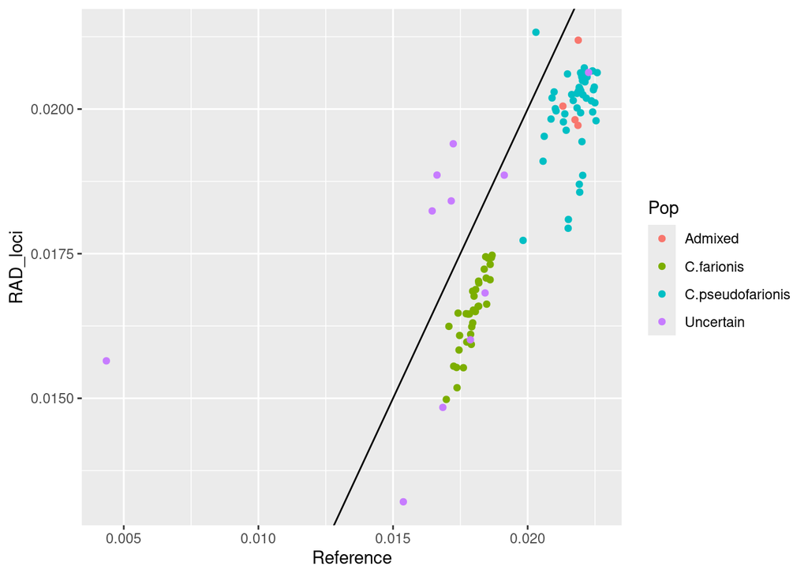

```r
library(tidyr)
library(kableExtra)
indH <- read.table('summary_indH.txt', header = TRUE)
onlyH <- pivot_wider(
   indH[, c('Ind', 'Pop', 'Assembly', 'H')],
   id_cols = c(1, 2),
   names_from = 'Assembly',
   values_from = 'H'
)
class(onlyH) <- 'data.frame'
ggplot(onlyH, aes(x = Reference, y = RAD_loci, color = Pop)) +
   geom_point() + geom_abline(slope = 1, intercept = 0)
```

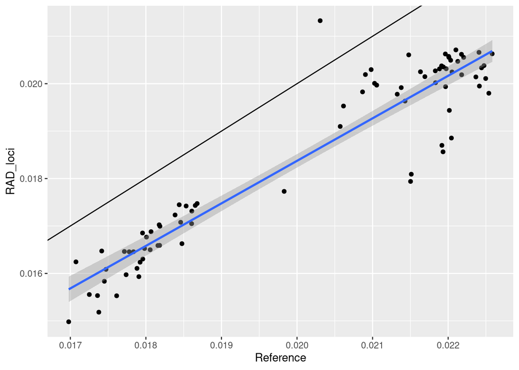

```r
f <- onlyH$Pop %in% c('C.farionis', 'C.pseudofarionis')
ggplot(onlyH[f,], aes(x = Reference, y = RAD_loci)) +
   geom_point() + geom_smooth(method = 'lm') +
   geom_abline(intercept = 0, slope = 1)
```

```r
summaryH <- data.frame(
   Population = rep(c('C. pseudofarionis', 'C. farionis'), each = 2),
   Assembly   = rep(c('Reference', 'RAD loci'), 2),
   MeanIndH   = c(mean(onlyH[onlyH$Pop == 'C.pseudofarionis', 'Reference']),
                  mean(onlyH[onlyH$Pop == 'C.pseudofarionis', 'RAD_loci']),
                  mean(onlyH[onlyH$Pop == 'C.farionis', 'Reference']),
                  mean(onlyH[onlyH$Pop == 'C.farionis', 'RAD_loci'])),
   Tajima     = c(pse.ref.pi.T, pse.rad.pi.T, far.ref.pi.T, far.rad.pi.T),
   Watterson  = c(pse.ref.pi.W, pse.rad.pi.W, far.ref.pi.W, far.rad.pi.W)
)
kable(summaryH) %>% kable_styling()
```

| Population | Assembly | MeanIndH | Tajima | Watterson |
| --- | --- | --- | --- | --- |
| C. pseudofarionis | Reference | 0.0217378 | 0.0185872 | 0.0196614 |
| C. pseudofarionis | RAD loci | 0.0199677 | 0.0163956 | 0.0193756 |
| C. farionis | Reference | 0.0179526 | 0.0191581 | 0.0236169 |
| C. farionis | RAD loci | 0.0164897 | 0.0151063 | 0.0201519 |

Individual levels of heterozygosity are estimated a bit higher when using the genome reference than when using RAD loci. No idea why. At least, the correlation is good. Surprisingly, *C. pseudofarionis* individuals seem to be more heterozygous than *C. farionis* ones, despite the two populations having very similar population-wide nucleotide diversities. This suggests *C. farionis* may be more inbred.

Admixed individuals are estimated to be between 62 and 64% of *C. pseudofarionis* ancestry, and I expected them to be significantly more heterozygous than other *C. pseudofarionis* individuals. But it is not the case.

# Individual inbreeding coefficients

```bash
RADBAM=../2024-10-04/BAM
REFBAM=../2023-05-18/BAM
RADREF=../2024-10-04/radloci.fa
REFREF=../2023-05-15/assembly.fasta

if [ ! -d ref/F ]; then mkdir ref/F; fi
if [ ! -d rad/F ]; then mkdir rad/F; fi

if [ ! -e ref/F/all.F ]; then
   if [ ! -e ref/F/all.glf ]; then
      if [ ! -e ref/F/all.list ]; then
         find $REFBAM -name '*.bam' > ref/F/all.list
      fi
      if [ ! -e ref/F/all.glf.gz ]; then
         angsd -b ref/F/all.list \
               -ref $REFREF \
               -rf ref/indH/goodchr.txt \
               -sites ref/indH/sites.txt \
               -out ref/F/all \
               -doGlf 3 \
               -GL 1 \
               -doMajorMinor 1 \
               -minmapQ 30 \
               -minQ 30 \
               -only_proper_pairs 1 \
               -baq 1 \
               -minInd 77 \
               -setMinDepthInd 4 \
               -nThreads 8 2> ref/F/all.err
      fi
      gunzip ref/F/all.glf.gz
   fi
   NSITES=$(tail -n 50 ref/F/all.err | grep "retained after filtering:" | gawk '{print $NF}')
   ngsF --n_ind $(cat ref/F/all.list | wc -l) \
        --n_sites $NSITES \
        --glf ref/F/all.glf \
        --out ref/F/all.F
fi

if [ ! -e rad/F/all.F ]; then
   if [ ! -e rad/F/all.glf ]; then
      if [ ! -e rad/F/all.list ]; then
         find $RADBAM -name '*.bam' > rad/F/all.list
      fi
      if [ ! -e rad/F/all.glf.gz ]; then
         angsd -b rad/F/all.list \
               -ref $RADREF \
               -rf rad/indH/goodchr.txt \
               -sites rad/indH/sites.txt \
               -out rad/F/all \
               -doGlf 3 \
               -GL 1 \
               -doMajorMinor 1 \
               -minmapQ 30 \
               -minQ 30 \
               -only_proper_pairs 1 \
               -baq 1 \
               -minInd 77 \
               -setMinDepthInd 4 \
               -nThreads 8 2> rad/F/all.err
      fi
      gunzip rad/F/all.glf.gz
   fi
   NSITES=$(tail -n 50 rad/F/all.err | grep "retained after filtering:" | gawk '{print $NF}')
   ngsF --n_ind $(cat rad/F/all.list | wc -l) \
        --n_sites $NSITES \
        --glf rad/F/all.glf \
        --out rad/F/all.F
fi

if [ ! -e summary_F.txt ]; then
   echo -e "Ind\tPop\tAssembly\tF" > summary_F.txt
   paste <(cat ref/F/all.list | xargs basename -s .bam) ref/F/all.F | \
   grep -f pseudofarionis.txt | \
   gawk '{
      print $1 "\tC.pseudofarionis\tReference\t" $2
   }' >> summary_F.txt

   paste <(cat ref/F/all.list | xargs basename -s .bam) ref/F/all.F | \
   grep -f farionis.txt | \
   gawk '{
      print $1 "\tC.farionis\tReference\t" $2
   }' >> summary_F.txt

   paste <(cat ref/F/all.list | xargs basename -s .bam) ref/F/all.F | \
   grep -f admixed.txt | \
   gawk '{
      print $1 "\tAdmixed\tReference\t" $2
   }' >> summary_F.txt

   paste <(cat ref/F/all.list | xargs basename -s .bam) ref/F/all.F | \
   grep -f uncertain.txt | \
   gawk '{
      print $1 "\tUncertain\tReference\t" $2
   }' >> summary_F.txt

   paste <(cat rad/F/all.list | xargs basename -s .bam) rad/F/all.F | \
   grep -f pseudofarionis.txt | \
   gawk '{
      print $1 "\tC.pseudofarionis\tRAD_loci\t" $2
   }' >> summary_F.txt

   paste <(cat rad/F/all.list | xargs basename -s .bam) rad/F/all.F | \
   grep -f farionis.txt | \
   gawk '{
      print $1 "\tC.farionis\tRAD_loci\t" $2
   }' >> summary_F.txt

   paste <(cat rad/F/all.list | xargs basename -s .bam) rad/F/all.F | \
   grep -f admixed.txt | \
   gawk '{
      print $1 "\tAdmixed\tRAD_loci\t" $2
   }' >> summary_F.txt

   paste <(cat rad/F/all.list | xargs basename -s .bam) rad/F/all.F | \
   grep -f uncertain.txt | \
   gawk '{
      print $1 "\tUncertain\tRAD_loci\t" $2
   }' >> summary_F.txt
fi
```

```r
F <- read.table('summary_F.txt', header = TRUE)
Fwide <- pivot_wider(F, id_cols = c('Ind', 'Pop'),
                     names_from = 'Assembly',
                     values_from = 'F')
class(Fwide) <- 'data.frame'
f <- Fwide$Pop == 'Uncertain'
kable(Fwide[f,]) %>% kable_styling()
```

|  | Ind | Pop | Reference | RAD_loci |
| --- | --- | --- | --- | --- |
| 86 | N048Cma | Uncertain | 0.012704 | 0.013038 |
| 87 | S004Cma | Uncertain | 0.004657 | 0.006981 |
| 88 | N048Cmc | Uncertain | 0.014325 | 0.009585 |
| 89 | T165Cxa | Uncertain | 0.279814 | 0.206217 |
| 90 | S061Cma | Uncertain | 0.002060 | 0.002435 |
| 91 | L131Cmb | Uncertain | 0.000130 | 0.000201 |
| 92 | S004Cmb | Uncertain | 0.010881 | 0.017565 |
| 93 | N044Cx2 | Uncertain | 0.000413 | 0.000832 |
| 94 | S061Cmb | Uncertain | 0.002477 | 0.003579 |
| 95 | S031Cmc | Uncertain | 0.270148 | 0.199517 |
| 96 | N048Cmb | Uncertain | 0.009991 | 0.003140 |

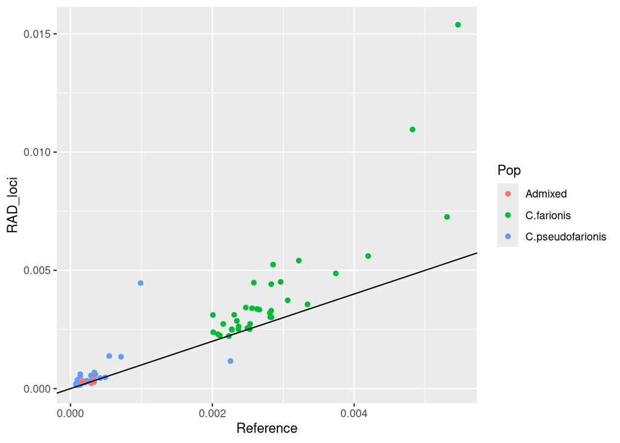

```r
ggplot(Fwide[! f,], aes(x = Reference, y = RAD_loci, color = Pop)) +
   geom_point() + geom_abline(slope = 1, intercept = 0)
```

```r
summaryH$F <- c(mean(Fwide[Fwide$Pop == 'C.pseudofarionis', 'Reference']),
                mean(Fwide[Fwide$Pop == 'C.pseudofarionis', 'RAD_loci']),
                mean(Fwide[Fwide$Pop == 'C.farionis', 'Reference']),
                mean(Fwide[Fwide$Pop == 'C.farionis', 'RAD_loci']))
kable(summaryH) %>% kable_styling()
```

| Population | Assembly | MeanIndH | Tajima | Watterson | F |
| --- | --- | --- | --- | --- | --- |
| C. pseudofarionis | Reference | 0.0217378 | 0.0185872 | 0.0196614 | 0.0002681 |
| C. pseudofarionis | RAD loci | 0.0199677 | 0.0163956 | 0.0193756 | 0.0004568 |
| C. farionis | Reference | 0.0179526 | 0.0191581 | 0.0236169 | 0.0028605 |
| C. farionis | RAD loci | 0.0164897 | 0.0151063 | 0.0201519 | 0.0040117 |

As expected, *C. farionis* has higher levels of inbreeding, which explains the difference between average individual heterozygosities and population-level nucleotide diversities. Inbreeding is low, in any case, except for two individuals: T165Cxa and S031Cmc, which are suspected to belong to a third species (*C. metoecus*?), and have much fewer loci covered.

# $F_{ST}$

In `2024-10-10` we already estimated the $F_{ST}$ between *C. farionis* in Langfjordvatn and *C. pseudofarionis* in Suopatjavri: 0.125520. But the estimate was based on artificially truncated SFSs, produced with a hard HWE threshold. Here, we have selected sites more carefully, and it is worth estimating the $F_{ST}$ between the two species again.

```bash
if [ ! -e summary_FST.txt ]; then
   for i in ref rad; do
      if [ ! -d $i/FST ]; then mkdir $i/FST; fi
      if [ ! -e $i/FST/farpse.fst.idx ]; then
         if [ ! -e $i/FST/farpse.2dsfs.ml ]; then
            realSFS -fold 1 \
                    -cores 16 \
                    $i/SFS/farionis.saf.idx \
                    $i/SFS/pseudofarionis.saf.idx \
                    1> $i/FST/farpse.2dsfs.ml \
                    2> $i/FST/farpse.2dsfs.err
         fi
         realSFS fst index $i/SFS/farionis.saf.idx \
                           $i/SFS/pseudofarionis.saf.idx \
                           -sfs $i/FST/farpse.2dsfs.ml \
                           -fstout $i/FST/farpse \
                           -whichFst 1 \
                           -cores 16 \
                           1> $i/FST/farpse.fst.log \
                           2> $i/FST/farpse.fst.err
      fi
   done
   echo -e "N.farionis\tN.pseudofarionis\tData\tFST.unweighted\tFST.weighted" > summary_FST.txt
   for i in ref rad; do
      NFar=$(cat $i/farionis.list | wc -l)
      NPse=$(cat $i/pseudofarionis.list | wc -l)
      echo -e "$NFar\t$NPse\t$i\t$(realSFS fst stats $i/FST/farpse.fst.idx 2> /dev/null)" >> summary_FST.txt
   done
fi
```

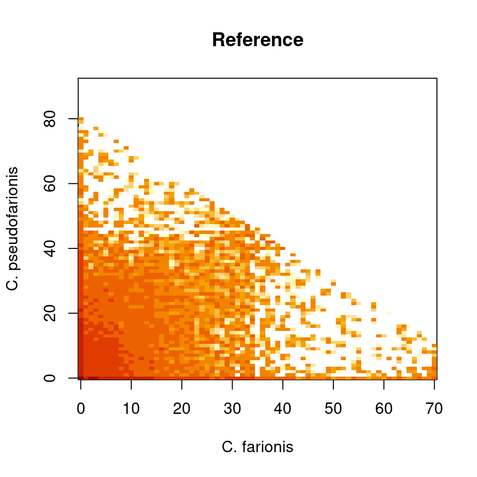

```r
library(kableExtra)
SFS2D.ref <- matrix(scan('ref/FST/farpse.2dsfs.ml', quiet = TRUE),
                    ncol = 2 * length(scan('ref/pseudofarionis.list',
                                           what = 'character',
                                           quiet = TRUE)) + 1,
                    nrow = 2 * length(scan('ref/farionis.list',
                                           what = 'character',
                                           quiet = TRUE)) + 1,
                    byrow = TRUE)
image(x = 0:(dim(SFS2D.ref)[1] - 1),
      y = 0:(dim(SFS2D.ref)[2] - 1),
      log(SFS2D.ref),
      main = 'Reference',
      xlab = 'C. farionis',
      ylab = 'C. pseudofarionis')
```

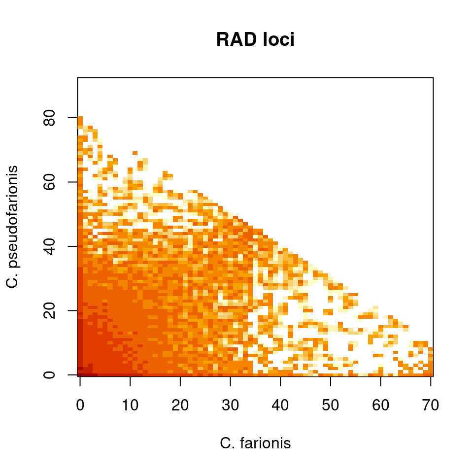

```r
SFS2D.rad <- matrix(scan('rad/FST/farpse.2dsfs.ml', quiet = TRUE),
                    ncol = 2 * length(scan('rad/pseudofarionis.list',
                                           what = 'character',
                                           quiet = TRUE)) + 1,
                    nrow = 2 * length(scan('rad/farionis.list',
                                           what = 'character',
                                           quiet = TRUE)) + 1,
                    byrow = TRUE)
image(x = 0:(dim(SFS2D.rad)[1] - 1),
      y = 0:(dim(SFS2D.rad)[2] - 1),
      log(SFS2D.rad),
      main = 'RAD loci',
      xlab = 'C. farionis',
      ylab = 'C. pseudofarionis')
```

```r
fst <- read.table('summary_FST.txt', header = TRUE)
kable(fst) %>% kable_styling(full_width = FALSE)
```

| N.farionis | N.pseudofarionis | Data | FST.unweighted | FST.weighted |
| --- | --- | --- | --- | --- |
| 35 | 46 | ref | 0.014596 | 0.133407 |
| 35 | 46 | rad | 0.012254 | 0.106031 |

# Individual depth of coverage

I am surprised the four apparently admixed individuals do not have any excess of heterozygosity. I wonder if their ambiguous genetic make-up could be the result of missing data, rather true admixture. To get depth of coverage per individual also allows me to test for any correlation between depth of coverage and heterozygosity or inbreeding coefficient.

```bash
RADREF=../2024-10-04/radloci.fa
REFREF=../2023-05-15/assembly.fasta

for i in ref rad; do
   if [ ! -d $i/depth ]; then mkdir $i/depth; fi
   if [ $i == 'ref' ]; then
      REF=$REFREF
   else
      REF=$RADREF
   fi
   for pop in admixed farionis pseudofarionis; do
      if [ $pop == 'admixed' ]; then
         RF=$i/indH/goodchr.txt
         SITES=$i/indH/sites.txt
      else
         RF=$i/SFS/unfiltered/$pop.chr.txt
         SITES=$i/SFS/unfiltered/$pop.sites.txt
      fi
      if [ ! -e $i/depth/$pop.depthSample ]; then
         angsd -bam $i/$pop.list \
               -ref $REF \
               -rf    $RF \
               -sites $SITES \
               -out   $i/depth/$pop \
               -doDepth 1 \
               -doCounts 1 \
               -maxDepth 1000 \
               -minmapQ 30 \
               -minQ 30 \
               -only_proper_pairs 1 \
               -baq 1 \
               -nThreads 4 \
               1> $i/depth/$pop.log \
               2> $i/depth/$pop.err &
      fi
   done
done
wait
```

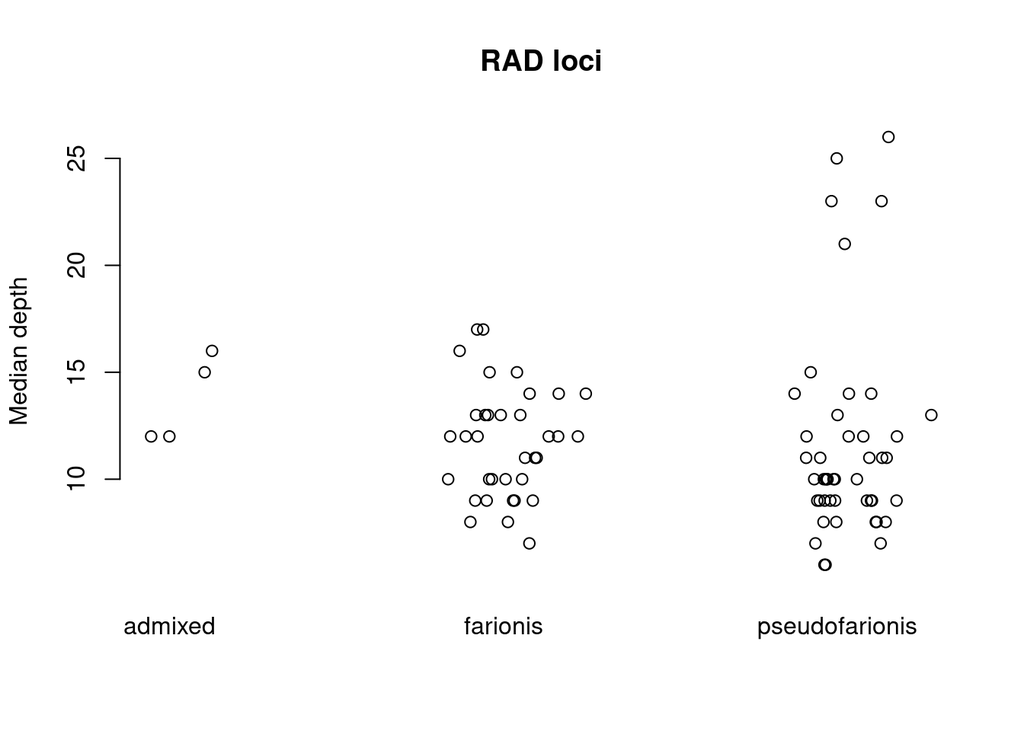

```r
perSample.rad <- rbind(
   matrix(scan('rad/depth/admixed.depthSample', quiet = TRUE),
          ncol = 1001, byrow = TRUE),
   matrix(scan('rad/depth/farionis.depthSample', quiet = TRUE),
          ncol = 1001, byrow = TRUE),
   matrix(scan('rad/depth/pseudofarionis.depthSample', quiet = TRUE),
          ncol = 1001, byrow = TRUE)
)
perSample.ref <- rbind(
   matrix(scan('ref/depth/admixed.depthSample', quiet = TRUE),
          ncol = 1001, byrow = TRUE),
   matrix(scan('ref/depth/farionis.depthSample', quiet = TRUE),
          ncol = 1001, byrow = TRUE),
   matrix(scan('ref/depth/pseudofarionis.depthSample', quiet = TRUE),
          ncol = 1001, byrow = TRUE)
)
samples <- basename(c(
   scan('rad/admixed.list',        what = 'character', quiet = TRUE),
   scan('rad/farionis.list',       what = 'character', quiet = TRUE),
   scan('rad/pseudofarionis.list', what = 'character', quiet = TRUE)
))
samples <- gsub('.bam', '', samples)
row.names(perSample.rad) <- samples
row.names(perSample.ref) <- samples
pops <- c(rep('admixed',
              length(scan('rad/admixed.list',
                          what = 'character',
                          quiet = TRUE))),
          rep('farionis',
              length(scan('rad/farionis.list',
                          what = 'character',
                          quiet = TRUE))),
          rep('pseudofarionis',
              length(scan('rad/pseudofarionis.list',
                          what = 'character',
                          quiet = TRUE))))
pops <- factor(pops, levels = c('admixed', 'farionis', 'pseudofarionis'))

# The total number of sites is different among populations,
# because of the population-specific filtering, based on F.

meanDepth.rad <- apply(perSample.rad, 1,
                       function(x) sum(0:1000 * x) / sum(x))
meanDepth.ref <- apply(perSample.ref, 1,
                       function(x) sum(0:1000 * x) / sum(x))
medianDepth.rad <- apply(perSample.rad, 1,
                         function(x) which(cumsum(x) >= sum(x) / 2)[1])
medianDepth.ref <- apply(perSample.ref, 1,
                         function(x) which(cumsum(x) >= sum(x) / 2)[1])

plot(as.numeric(pops) + rnorm(length(pops), 0, 0.1),
     medianDepth.rad, axes = FALSE, xlab = '', ylab = 'Median depth', main = 'RAD loci')
axis(1, at = 1:3, labels = levels(pops), tick = FALSE)
axis(2)
```

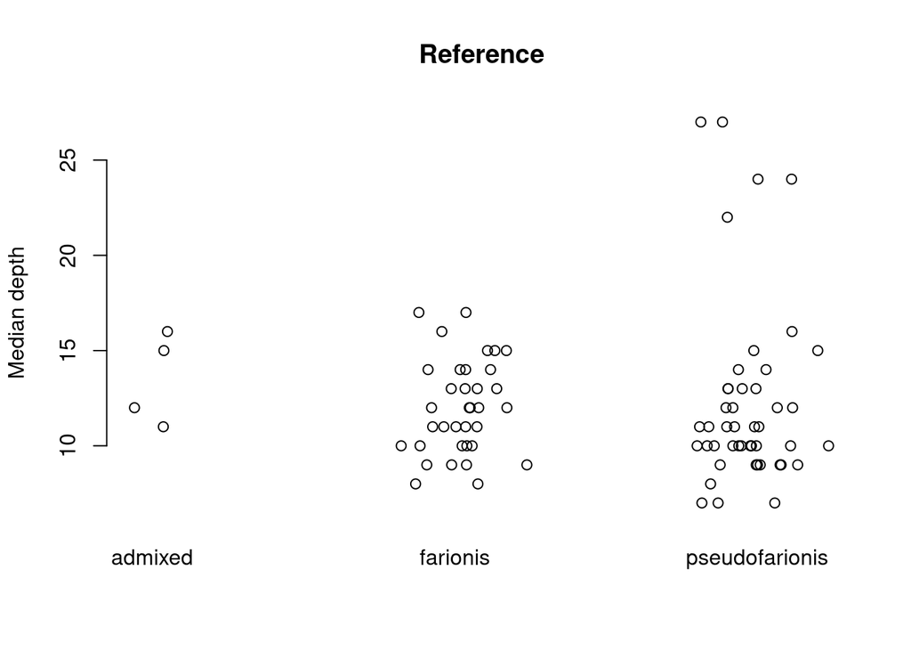

```r
plot(as.numeric(pops) + rnorm(length(pops), 0, 0.1),
     medianDepth.ref, axes = FALSE, xlab = '', ylab = 'Median depth', main = 'Reference')
axis(1, at = 1:3, labels = levels(pops), tick = FALSE)
axis(2)
```

The four admixed individuals do not have lower depth of coverage than the rest.

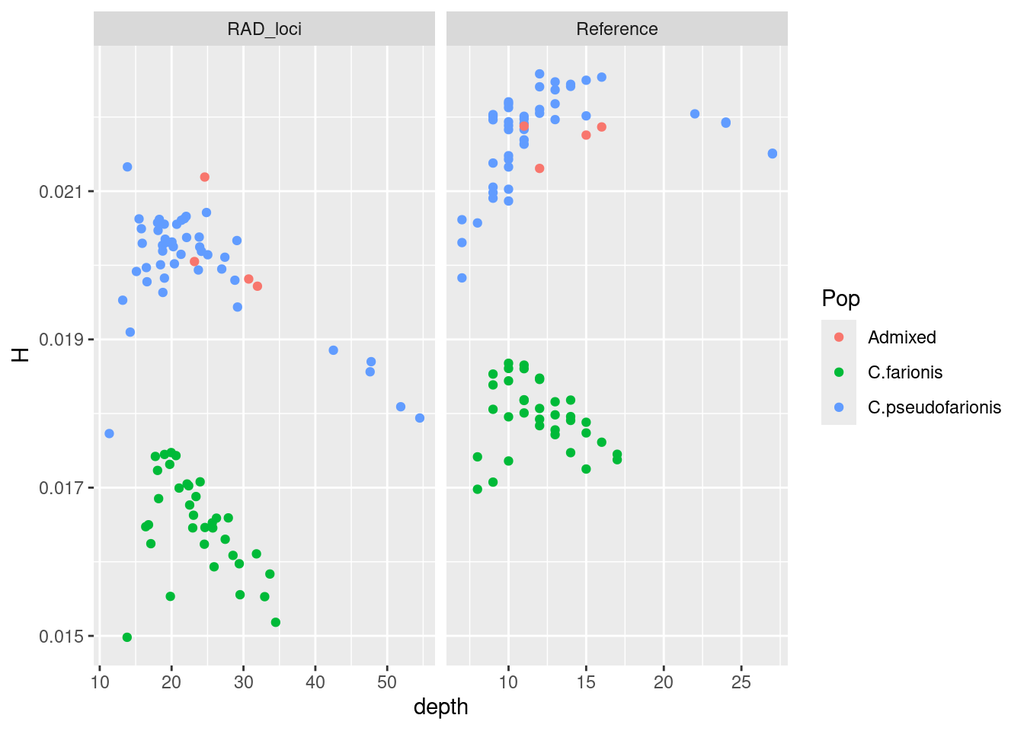

```r
indH <- read.table('summary_indH.txt', header = TRUE)
indH$depth <- meanDepth.rad[indH$Ind]
indH[indH$Assembly == 'Reference', 'depth'] <- medianDepth.ref[indH[indH$Assembly == 'Reference', 'Ind']]
f <- indH$Pop %in% c('Admixed', 'C.farionis', 'C.pseudofarionis')
ggplot(data = indH[f,], mapping = aes(x = depth, y = H, color = Pop)) + geom_point() + facet_wrap(~Assembly, scales = 'free_x')
```

# References

Kim, S.Y. and Lohmueller, K.E. and Albrechtsen, A. and Li, Y. and Korneliussen, T. and Tian, G. and Grarup, N. and Jiang, T. and Andersen, G. and Witte, D. and Jorgensen, T. and Hansen, T. and Pedersen, O. and Wang, J. and Nielsen, R. 2011. “Estimation of allele frequency and association mapping using next-generation sequencing data.” *BMC Bioinformatics* 12: 231.